# STAT 240 Discussion 3

## Group 325 (use the assigned group name/number)

**Remember**: you MUST complete this discussion in your assigned groups! If you are not able to be present, please try to join your group over Zoom (links provided in Canvas).

## Members Present

- ADD THE NAMES OF EVERYONE PRESENT
- MAKE THE NAME **BOLD** OF THE RESPONSIBLE PERSON TO UPLOAD THE FILES FOR THE GROUP

**Xianfu Luo** Jason Lee Dennis Luis_Aragon Rentao Tan

## Questions

### 1

The code below modifies the exoplanet data table, `planets`. Review the code and then answer the question below the code chunk. Some questions will require additional code to answer them.

```r
## Read in the csv files for all planets
## There is one row for each exoplanet publication
## Note that the file begins with a number of comment lines which we skip

planets = read_csv("../../data/exoplanets_default_2021-06-15.csv",
                   skip = 100) %>%
  select(pl_name, hostname, discoverymethod, disc_year, sy_pnum, pl_rade, pl_bmasse) %>%
  rename(planet = pl_name,
         star = hostname,
         method = discoverymethod,
         year = disc_year,
         number = sy_pnum,
         radius = pl_rade,
         mass = pl_bmasse)

### Add code here as needed to address the questions.
exoplanets_number = planets %>%
  select(year, number) %>%
  filter(year == "2000" | year == "2005" | year == "2010" | year == "2015") %>%
  group_by(year) %>%
  summarize(sum_number = sum(number))
exoplanets_number
```

```
## # A tibble: 4 × 2
##    year sum_number
##   <dbl>      <dbl>
## 1  2000         28
## 2  2005         56
## 3  2010        189
## 4  2015        307
```

```r
planets
```

```
## # A tibble: 4,401 × 7
##    planet                  star            method       year number radius  mass
##    <chr>                   <chr>           <chr>       <dbl>  <dbl>  <dbl> <dbl>
##  1 11 Com b                11 Com          Radial Vel…  2007      1     NA 6166.
##  2 11 UMi b                11 UMi          Radial Vel…  2009      1     NA 4685.
##  3 14 And b                14 And          Radial Vel…  2008      1     NA 1526.
##  4 14 Her b                14 Her          Radial Vel…  2002      1     NA 1481.
##  5 16 Cyg B b              16 Cyg B        Radial Vel…  1996      1     NA  566.
##  6 18 Del b                18 Del          Radial Vel…  2008      1     NA 3274.
##  7 1RXS J160929.1-210524 b 1RXS J160929.1… Imaging      2008      1     NA 3000
##  8 24 Boo b                24 Boo          Radial Vel…  2018      1     NA  289.
##  9 24 Sex b                24 Sex          Radial Vel…  2010      2     NA  632.
## 10 24 Sex c                24 Sex          Radial Vel…  2010      2     NA  273.
## # … with 4,391 more rows
```

> 1. What does the `skip = 100` argument to `read_csv()` do? Why is it necessary?

Skip the first 100 line of data, because for the first 100 line of the csv file, they are information about the column attribute.

> 2. What does the `rename()` function do to the data frame?

change the name of previous column name

> 3. After running the code chunk, how many observations are in the data set?

> 4. What are the combined number of exoplanets discovered in each of the years 2000, 2005, 2010, and 2015?

**For the remaining questions, use the `planets` data from Question 1.**

### 2

> Which methods are most commonly used to discover exoplanets?
- Create a bar graph that has the methods of exoplanet discovery on the x axis and counts of the number of planets discovered by each on the y axis.
- Give the graph a title and choose appropriate axis labels.
- The default graph might not have room to fit the tick labels without overwriting.
  - Use the function `theme()` to add a layer to the plot to rotate the axis labels
  - Try adding `theme( axis.text.x = element_text(angle=45, hjust=1) )` to the base plot
    - the `angle=45` argument rotates the labels by 45 degrees
    - the `hjust=1` argument justifies the end of each label at the same location

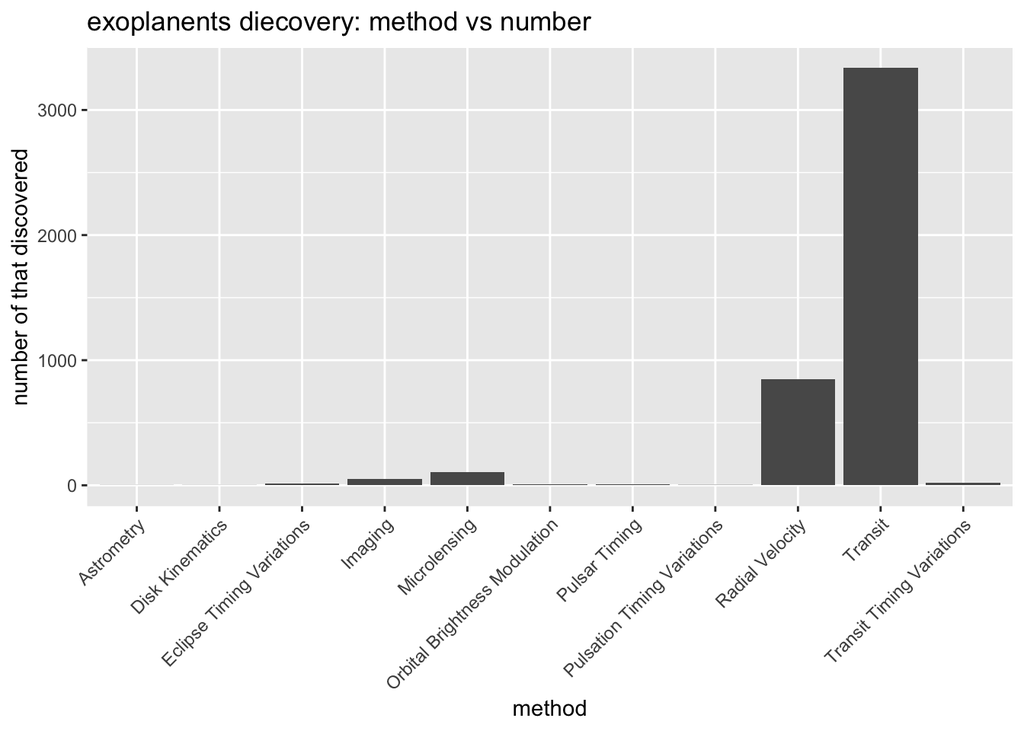

```r
ggplot(planets, aes(x = method)) +
  geom_bar() +
  xlab('method') +
  ylab('number of that discovered') +
  ggtitle('exoplanents diecovery: method vs number') +
  theme( axis.text.x = element_text(angle=45, hjust=1))
```

### 3

> Create a summary data frame with one row for each method which counts the number of planets disovered by that method. Arrange the rows from most to least planets discovered. There will be a column for method and a column for the counts.

```r
summary_data = planets %>%
  select(method, number) %>%
  group_by(method) %>%
  summarize(count = sum(number))
summary_data
```

```
## # A tibble: 11 × 2
##    method                        count
##    <chr>                         <dbl>
##  1 Astrometry                        1
##  2 Disk Kinematics                   1
##  3 Eclipse Timing Variations        24
##  4 Imaging                          72
##  5 Microlensing                    116
##  6 Orbital Brightness Modulation    14
##  7 Pulsar Timing                    13
##  8 Pulsation Timing Variations       2
##  9 Radial Velocity                1550
## 10 Transit                        6007
## 11 Transit Timing Variations        57
```

### 4

> Create a data set with one row per star and a column for the number of planets found by each star. Arrange the rows from the most to the least. How many stars are there in the data set? Which star has the most discovered exoplanets and how many are there?

```r
star_planets = planets %>%
  count(star) %>%
  arrange(desc(n))

star_planets
```

```
## # A tibble: 3,271 × 2
##    star           n
##    <chr>      <int>
##  1 KOI-351        8
##  2 TRAPPIST-1     7
##  3 HD 10180       6
##  4 HD 219134      6
##  5 HD 34445       6
##  6 K2-138         6
##  7 Kepler-11      6
##  8 Kepler-20      6
##  9 Kepler-80      6
## 10 TOI-178        6
## # … with 3,261 more rows
```

3271 stars and KOI-351 has the most discovered exoplanets, which is 8.

### 5

> What are the mean and median number of confirmed exoplanets around each star in this data base?
- Note: sometimes when using the `group_by()` command, the grouping persists. - You can remove unwanted grouping with the `ungroup()` command.

```r
star_planets %>%
  summarize(mean = mean(n), median = median(n))
```

```
## # A tibble: 1 × 2
##    mean median
##   <dbl>  <int>
## 1  1.35      1
```